# Final_Project_Draft

Jash Shah Prem Amal

2023-11-24

```r
data<-read.csv('Sleep_Efficiency.csv')
```

```r
head(data)
```

```
##   ID Age Gender          Bedtime      Wakeup.time Sleep.duration
## 1  1  65 Female 06-03-2021 01:00 06-03-2021 07:00            6.0
## 2  2  69   Male 05-12-2021 02:00 05-12-2021 09:00            7.0
## 3  3  40 Female 25-05-2021 21:30 25-05-2021 05:30            8.0
## 4  4  40 Female 03-11-2021 02:30 03-11-2021 08:30            6.0
## 5  5  57   Male 13-03-2021 01:00 13-03-2021 09:00            8.0
## 6  6  36 Female 01-07-2021 21:00 01-07-2021 04:30            7.5
##   Sleep.efficiency REM.sleep.percentage Deep.sleep.percentage
## 1             0.88                   18                    70
## 2             0.66                   19                    28
## 3             0.89                   20                    70
## 4             0.51                   23                    25
## 5             0.76                   27                    55
## 6             0.90                   23                    60
##   Light.sleep.percentage Awakenings Caffeine.consumption Alcohol.consumption
## 1                     12          0                    0                   0
## 2                     53          3                    0                   3
## 3                     10          1                    0                   0
## 4                     52          3                   50                   5
## 5                     18          3                    0                   3
## 6                     17          0                   25                   0
##   Smoking.status Exercise.frequency
## 1            Yes                  3
## 2            Yes                  3
## 3             No                  3
## 4            Yes                  1
## 5             No                  3
## 6             No                  1
```

```r
#install.packages("devtools")
```

```r
#devtools::install_github("vqv/ggbiplot")
```

```r
#install.packages('ggbiplot')
library(ggplot2)
library(vcd)
library(tidyverse)
library(ade4)
library(broom)
library(rstanarm)
library(caret)
#library(ggbiplot)
```

# Initial Exploratory Data Analysis

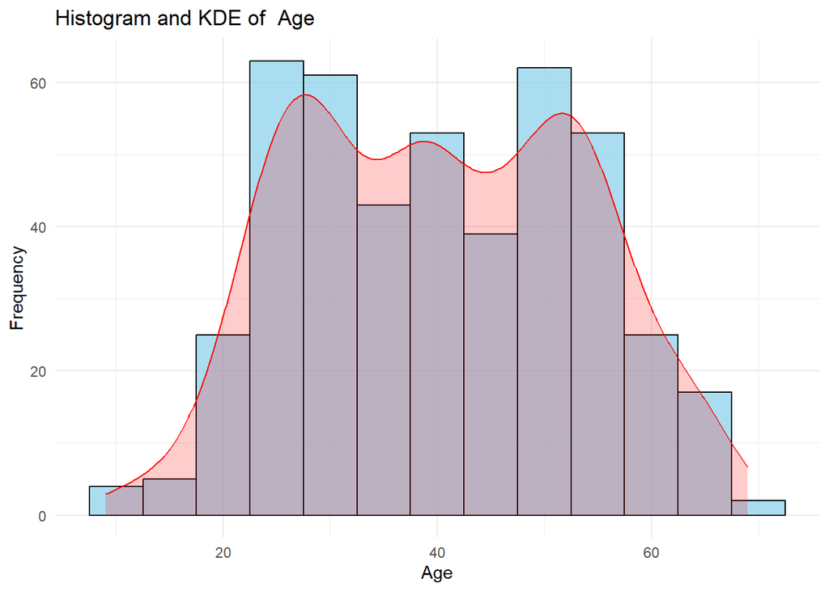

```r
histogram_age <- ggplot(data, aes(x = Age)) +
  geom_histogram(binwidth = 5, fill = "skyblue", color = "black", alpha = 0.7) +
 geom_density(aes(y = ..count.. * 5), color = "red", fill = "red", alpha = 0.2) +
  ggtitle("Histogram and KDE of  Age") +
  labs(x = "Age", y = "Frequency") +
  theme_minimal()
print(histogram_age)
```

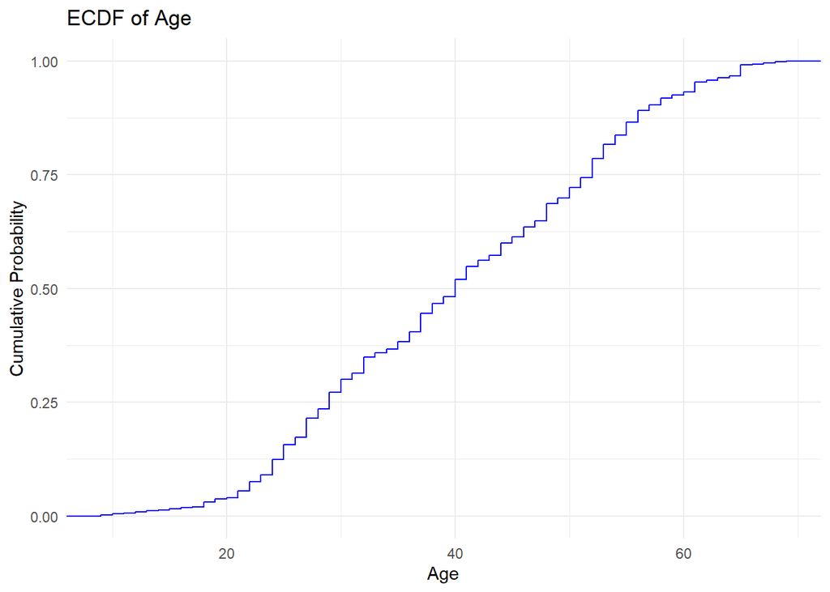

```r
# Empirical Cumulative Distribution Function (ECDF) of Age
ecdf_age <- ggplot(data, aes(x = Age)) +
  stat_ecdf(geom = "step", color = "blue") +
  ggtitle("ECDF of Age") +
  labs(x = "Age", y = "Cumulative Probability") +
  theme_minimal()
print(ecdf_age)
```

Summary Statistics:

The histogram indicates that the majority of individuals fall between the ages of 20 and 60.

Outliers:

There are a few instances of individuals aged 65 and 68, which could be considered outliers depending on the context of your analysis. Age Range:

The ages range from as low as 9 years to as high as 69 years, covering a broad spectrum. Distribution Shape:

The ECDF plot shows a cumulative distribution of ages, and you can observe how quickly the ages accumulate.